# Methods & Benchmarks Overview

- Show All Code
- Hide All Code
- View Source

Every model in uncertainty_flow, when to use it, and how they compare on real benchmarks

Published

May 4, 2026

A guide to every model in `uncertainty_flow`, when to use it, and how they compare on real benchmarks.

```python
import polars as pl
```

```python
raw = pl.read_csv("../docs/benchmarks/comparison_table.csv", try_parse_dates=False)
print(f"Loaded {raw.height} benchmark rows across {raw['dataset'].n_unique()} datasets and {raw['model'].n_unique()} models")
```

```
Loaded 36 benchmark rows across 3 datasets and 12 models
```

## Model Methodology Reference

Each model returns a `DistributionPrediction` object. Here is what each one does and when to reach for it.

### ConformalRegressor

- **Family:** Tabular wrapper
- **Coverage:** Mathematical guarantee (exchangeability assumption) — Post-sort non-crossing
- **Use when:** You already have a scikit-learn regressor and want calibrated intervals on tabular data.
- **Method:** Splits data into train + calibration, computes residual quantiles on calibration, adds them to test predictions.
- **Multivariate:** No
- **Dependencies:** `scikit-learn` only

### ConformalForecaster

- **Family:** Forecasting wrapper
- **Coverage:** Mathematical guarantee (with temporal correction) — Post-sort non-crossing
- **Use when:** Forecasting time series where interval calibration matters more than raw speed.
- **Method:** Constructs lag features, splits temporally, computes residual quantiles from the end of training.
- **Multivariate:** Yes (copula-aware joint sampling)
- **Dependencies:** `scikit-learn` only

### QuantileForestForecaster

- **Family:** Native tree model
- **Coverage:** Empirical only — By-construction non-crossing
- **Use when:** You need a fast, interpretable quantile forecaster without deep learning.
- **Method:** Random Forest stores full leaf distributions, enabling true quantile computation (not split-conformal).
- **Multivariate:** Yes (copula-aware joint sampling)
- **Dependencies:** `scikit-learn` only

### DeepQuantileNet / DeepQuantileNetTorch

- **Family:** Native neural model
- **Coverage:** Empirical only — Post-sort non-crossing
- **Use when:** Nonlinear signals that tree models underfit. Torch backend for GPU/accelerator support.
- **Method:** Multi-quantile MLP with shared trunk (sklearn) or PyTorch backend.
- **Multivariate:** Yes
- **Dependencies:** `scikit-learn` (+ `torch` for Torch variant)

### BayesianQuantileRegressor

- **Family:** Bayesian (optional numpyro)
- **Coverage:** Posterior-based — Post-sort non-crossing
- **Use when:** You need full posterior distributions with credible intervals (not discrete quantiles).
- **Warning:** Default settings over-regularize (horseshoe prior). Requires hyperparameter tuning.
- **Multivariate:** No
- **Dependencies:** `numpyro` + `jax` (optional)

### Additional Modules

| Module | Purpose | Coverage |
| --- | --- | --- |
| **CausalUncertaintyEstimator** | Treatment effect (CATE/ATE) estimation with conformal CIs | Conformal on CATE |
| **CrossModalAggregator** | Combine predictions from separate feature groups | Inherited from base models |
| **ConformalRiskControl** | Control expected loss instead of coverage | Risk-bounded |
| **EnsembleDecomposition** | Bootstrap-based aleatoric/epistemic decomposition | Refit-based |
| **FeatureLeverageAnalyzer** | Score features by impact on interval width | Correlation-based |
| **UncertaintyExplainer** | Find feature changes that reduce uncertainty | Counterfactual search |

## Overall Rankings

Models ranked by average Winkler score @ 90% confidence across all datasets.

```python
overall = (
    raw.group_by("model")
    .agg(
        [
            pl.col("winkler_90").mean().alias("avg_winkler"),
            pl.col("coverage_90").mean().alias("avg_coverage"),
            pl.col("mae").mean().alias("avg_mae"),
            pl.col("calibration_error").mean().alias("avg_cal_error"),
            pl.col("timing_mean").mean().alias("avg_time_sec"),
            pl.col("dataset").count().alias("datasets"),
        ]
    )
    .sort("avg_winkler")
)
overall
```

shape: (12, 7)

| model str | avg_winkler f64 | avg_coverage f64 | avg_mae f64 | avg_cal_error f64 | avg_time_sec f64 | datasets u32 |
| --- | --- | --- | --- | --- | --- | --- |
| "quantile-forest" | 107.486333 | 0.835 | 17.191233 | 0.069667 | 0.468642 | 3 |
| "conformal-forecaster" | 134.0139 | 0.8644 | 20.834967 | 0.101467 | 0.31793 | 3 |
| "random-forest" | 134.412367 | 0.713 | 14.168767 | 0.293 | 0.102458 | 3 |
| "gradient-boosting" | 151.7409 | 0.720333 | 23.6311 | 0.267667 | 0.328896 | 3 |
| "conformal-regressor" | 151.7409 | 0.720333 | 23.6311 | 0.267667 | 0.324499 | 3 |
| … | … | … | … | … | … | … |
| "deep-quantile" | 264.1989 | 0.899667 | 47.676967 | 0.003 | 1.99643 | 3 |
| "deep-quantile-torch" | 264.454633 | 0.928 | 41.1705 | 0.032667 | 1.522282 | 3 |
| "naive-forecast" | 580.662633 | 0.362333 | 100.222867 | 0.537667 | 0.00039 | 3 |
| "moving-average" | 921.0943 | 0.303 | 115.2421 | 0.597 | 0.00219 | 3 |
| "bayesian-quantile" | 8.6816e6 | 0.000667 | 439022.567433 | 0.899333 | 11.059066 | 3 |

## By Dataset

```python
dataset = "weather"
df_ds = raw.filter(pl.col("dataset") == dataset).sort("winkler_90")
df_ds
```

shape: (12, 19)

| dataset str | domain str | model str | coverage_90 f64 | coverage_80 f64 | sharpness_90 f64 | sharpness_80 f64 | winkler_90 f64 | winkler_80 f64 | pinball_loss f64 | crps f64 | mae f64 | rmse f64 | calibration_error f64 | train_time_sec f64 | timing_mean f64 | timing_std i64 | memory_delta_mb i64 | n_runs i64 |
| --- | --- | --- | --- | --- | --- | --- | --- | --- | --- | --- | --- | --- | --- | --- | --- | --- | --- | --- |
| "weather" | "Climate" | "deep-quantile-torch" | 0.956 | 0.849 | 0.0136 | 0.0093 | 0.0149 | 0.0122 | 0.0007 | 0.002 | 0.0026 | 0.0039 | 0.056 | 1.761 | 1.761451 | 0 | 0 | 1 |
| "weather" | "Climate" | "conformal-forecaster" | 0.9359 | 0.8417 | 0.0223 | 0.0144 | 0.0279 | 0.0211 | 0.0011 | 0.0033 | 0.0042 | 0.0058 | 0.0359 | 0.058 | 0.058437 | 0 | 0 | 1 |
| "weather" | "Climate" | "conformal-regressor" | 0.964 | 0.927 | 0.0323 | 0.0287 | 0.0347 | 0.0309 | 0.0019 | 0.0044 | 0.0078 | 0.0094 | 0.064 | 0.058 | 0.057803 | 0 | 0 | 1 |
| "weather" | "Climate" | "gradient-boosting" | 0.964 | 0.927 | 0.0323 | 0.0287 | 0.0347 | 0.0309 | 0.0019 | 0.0044 | 0.0078 | 0.0094 | 0.064 | 0.057 | 0.056902 | 0 | 0 | 1 |
| "weather" | "Climate" | "quantile-forest" | 0.841 | 0.784 | 0.0132 | 0.0107 | 0.0399 | 0.027 | 0.0013 | 0.0038 | 0.0046 | 0.0081 | 0.059 | 0.125 | 0.124757 | 0 | 0 | 1 |
| … | … | … | … | … | … | … | … | … | … | … | … | … | … | … | … | … | … | … |
| "weather" | "Climate" | "linear-regression" | 0.911 | 0.871 | 0.0444 | 0.0388 | 0.0558 | 0.0477 | 0.0024 | 0.0071 | 0.0101 | 0.0131 | 0.011 | 0.006 | 0.006129 | 0 | 0 | 1 |
| "weather" | "Climate" | "ridge-regression" | 0.913 | 0.869 | 0.0456 | 0.0394 | 0.0565 | 0.0484 | 0.0024 | 0.0073 | 0.0105 | 0.0135 | 0.013 | 0.005 | 0.004902 | 0 | 0 | 1 |
| "weather" | "Climate" | "moving-average" | 0.268 | 0.197 | 0.0234 | 0.0182 | 0.3552 | 0.204 | 0.0142 | 0.0234 | 0.0269 | 0.0319 | 0.632 | 0.003 | 0.002656 | 0 | 0 | 1 |
| "weather" | "Climate" | "naive-forecast" | 0.271 | 0.203 | 0.0282 | 0.022 | 0.3822 | 0.2229 | 0.0158 | 0.0258 | 0.0299 | 0.0353 | 0.629 | 0.001 | 0.000535 | 0 | 0 | 1 |
| "weather" | "Climate" | "bayesian-quantile" | 0.0 | 0.0 | 0.2882 | 0.2882 | 199.6684 | 99.9783 | 5.2598 | 10.0637 | 10.027 | 11.5947 | 0.9 | 3.72 | 3.719742 | 0 | 0 | 1 |

## Model Comparison Plot

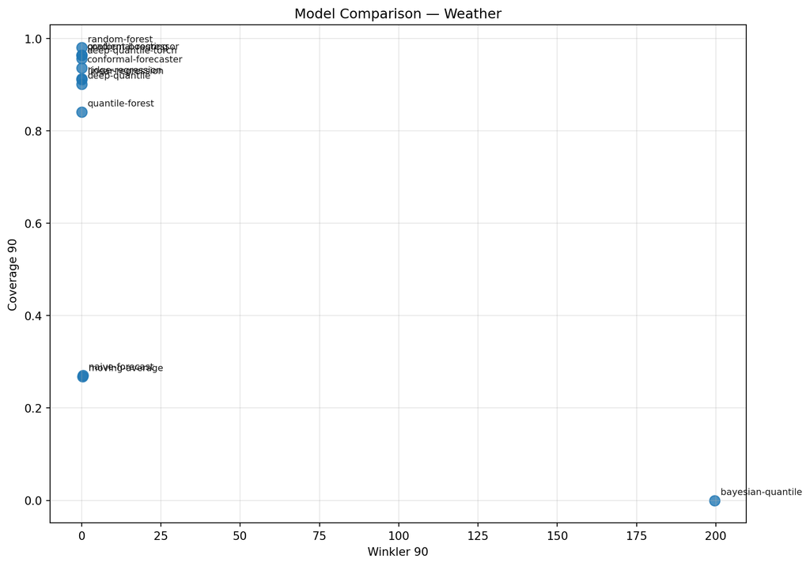

```python
import matplotlib.pyplot as plt

x_metric = "winkler_90"
y_metric = "coverage_90"

df_plot = raw.filter(pl.col("dataset") == "weather")
x_vals = df_plot[x_metric].to_numpy()
y_vals = df_plot[y_metric].to_numpy()
labels = df_plot["model"].to_list()

fig, ax = plt.subplots(figsize=(10, 7))
ax.scatter(x_vals, y_vals, s=80, alpha=0.8)

for i, label in enumerate(labels):
    ax.annotate(
        label,
        (x_vals[i], y_vals[i]),
        fontsize=8,
        alpha=0.9,
        xytext=(5, 5),
        textcoords="offset points",
    )

ax.set_xlabel(x_metric.replace("_", " ").title())
ax.set_ylabel(y_metric.replace("_", " ").title())
ax.set_title("Model Comparison — Weather")
ax.grid(True, alpha=0.3)
plt.tight_layout()
plt.show()
```

## Key Findings

### Finding 1: deep-quantile-torch Dominates on Low-Dimensional Data

Best Winkler on weather (0.0149) and exchange_rate (0.1351). Captures nonlinear relationships tree-based methods miss on smaller feature spaces. Struggles on 320-feature electricity (793.21 Winkler).

### Finding 2: deep-quantile Has the Best Calibration

Near-perfect calibration error on weather (0.001) and exchange_rate (0.003). 90.1% coverage on weather is essentially exact. Wider intervals than torch version.

### Finding 4: BayesianQuantileRegressor Fails on Default Settings

0% coverage on weather/electricity, 0.2% on exchange_rate. Horseshoe prior over-regularizes. Requires significant tuning.

### Finding 5: conformal-regressor and gradient-boosting Are Identical

Both wrap `GradientBoostingRegressor` in `ConformalRegressor` with the same defaults — byte-identical.

### Finding 7: Speed vs Quality Tradeoff

[output not shown]

## Recommendations

| Scenario | Model | Why |
| --- | --- | --- |
| **Low-dimensional, best accuracy** | `deep-quantile-torch` | Best Winkler on weather & exchange_rate |
| **High-dimensional, best accuracy** | `quantile-forest` | Dominates on electricity (320 features) |
| **Best calibration** | `deep-quantile` | Near-exact 90% coverage across datasets |
| **Fast production** | `conformal-forecaster` | Best quality in medium speed tier |
| **Guaranteed coverage** | `conformal-regressor` or `conformal-forecaster` | Mathematical coverage guarantee |
| **Asymmetric costs** | `ConformalRiskControl` | Control expected loss, not coverage |
| **Full posterior** | `BayesianQuantileRegressor` | Needs careful tuning first |

## Data Source

Benchmark results from `docs/benchmarks/README.md` (April 26, 2026). 1,000 obs per dataset, horizon=3, auto-tuning disabled. See `docs/benchmarks/comparison_table.csv` for full raw data.